# Estimating M with One Monotone Anchor per Ordering

## Question

We tested how estimating the number of latent sample orderings changes when each ordering has **one monotone trajectory** and its remaining trajectories are **smooth with turning points**. The comparison uses the same 90 datasets’ latent positions, feature groups, and measurement noise as the [all-monotone benchmark](https://aguerozz.github.io/InferOrder/estimate_intrinsic_m.html).

With adaptive empirical Bayes (EB), exact recovery changes from **87/90** in the all-monotone setting to **60/90** with one monotone anchor. With a fixed uniform ordering prior and forward selection, it changes from **90/90** to **88/90**.

## Simulation design

Each dataset contains **300 samples and 60 features**, arranged in balanced groups following **3, 4, or 5 independent latent orderings**. This gives 20, 15, or 12 features per ordering. For sample $i$ and feature $j$,

$$X_{ij}=f_j(t_{i,z_j})+\epsilon_{ij},$$

where $z_j$ identifies the feature’s ordering and the latent positions are independent Uniform$(0,1)$ draws. Within each group, the first feature retains its original monotone trajectory. The other features follow random smooth mixtures,

$$f_j(t)=\sum_{k=2}^{4}
\frac{a_{jk}\sin(k\pi t)+b_{jk}\cos(k\pi t)}{k^2}.$$

The coefficients $a_{jk}$ and $b_{jk}$ are independent standard normal draws.

We retain draws whose analytic derivative takes both signs on a fixed 1,001-point grid, producing trajectories with peaks and troughs. Each noiseless feature is centered and scaled to sample variance one. The monotone anchor preserves a unique direction of progression through the complete noiseless feature vector.

The variance signal-to-noise ratio is **1, 4, or 16**, with **10 datasets per condition**. Each modified dataset retains its baseline’s latent positions, feature membership, monotone anchor, and exact Gaussian-noise realization. The paired comparison therefore changes the shapes of the other trajectories while preserving these settings. Both estimation methods receive the same modified input matrix.

### Simulated trajectories and observations

The following figures show replicate 1 from every condition. Each row is a true ordering and each column is an SNR setting. Blue shows the monotone anchor; orange and purple show the next two smooth trajectories in the group.

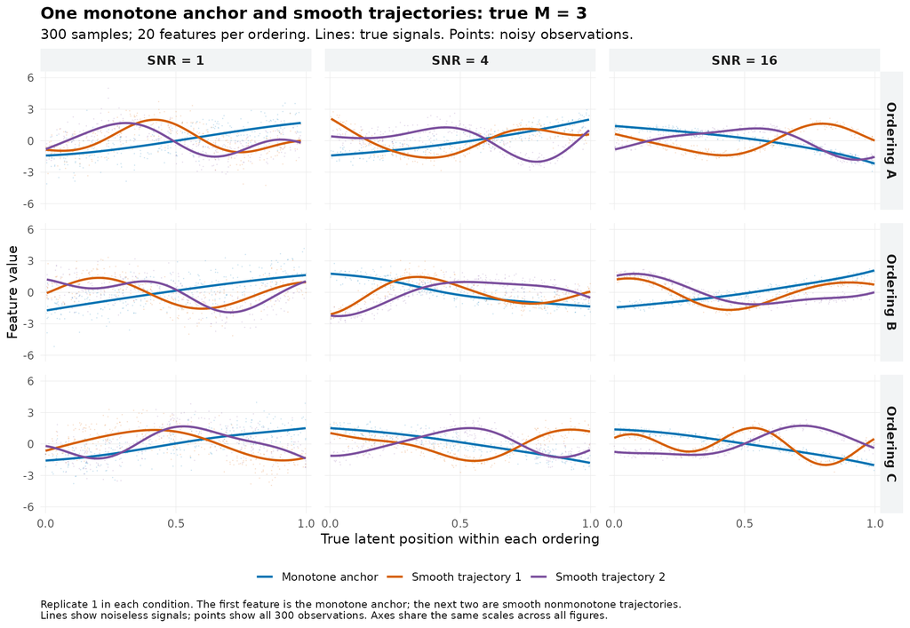

True M = 3: replicate 1 at SNR 1, 4, and 16. Rows identify the three true orderings, each containing 20 features. Lines show the first three noiseless trajectories in each group; blue is the monotone anchor. Points show all 300 noisy observations for each displayed feature. Axes share the same scales across all design figures.

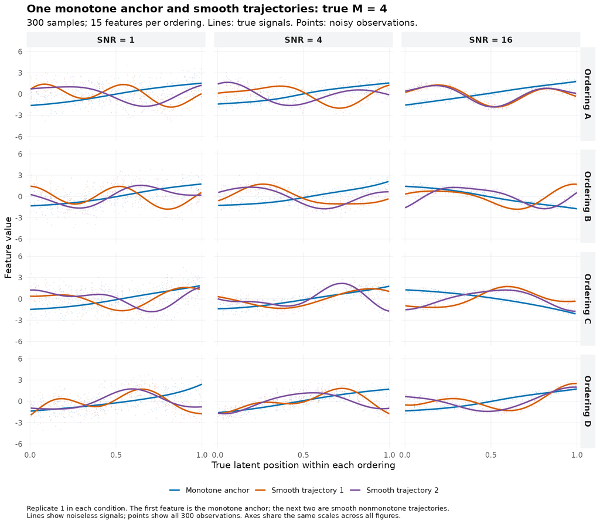

True M = 4: replicate 1 at each SNR. Rows identify the four true orderings, each containing 15 features. Blue lines show the monotone anchors; orange and purple show the next two smooth trajectories. Points show all 300 observations per displayed feature, with the same axes used in the other design figures.

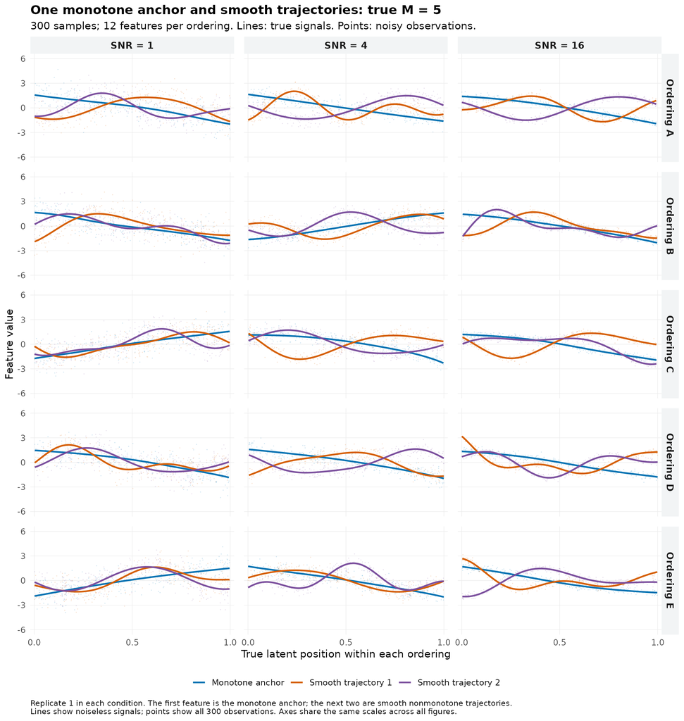

True M = 5: replicate 1 at each SNR. Rows identify the five true orderings, each containing 12 features. Blue lines show the monotone anchors; orange and purple show the next two smooth trajectories. Points show all 300 observations per displayed feature. Axes match the other design figures.

## Methods

Both methods use **MPCurver 0.3.2** and coordinate-ascent variational inference (CAVI), with the fitting settings of the all-monotone study. These include 50 grid positions, second-order random-walk smoothing with `ridge = 0`, adaptive cell-position priors, and estimated feature-specific noise and smoothness. Initialization uses absolute Spearman similarity, single-linkage feature grouping, and Isomap within each group; a singleton is initialized by ranking its feature.

- **Adaptive EB** starts with eight ordering slots and estimates their assignment-prior weights.
- **Uniform + forward** fixes the assignment prior to $1/M$, starts at $M=1$, and adds slots up to eight. It accepts a candidate when its converged temperature-one, soft-assignment ELBO improves and stops at the first non-improvement.

The reported **effective M** is the number of slots whose mean posterior feature-assignment probability exceeds $10^{-12}$. Each candidate uses one initialization and anneals from temperature five to one. Convergence requires absolute ELBO change divided by $ND$ below $10^{-6}$, with a 10,000-sweep limit per candidate. The study records a terminal unresolved outcome if a candidate required for the estimate fails to converge.

### Trajectory shape and initialization

The modified trajectories have lower within-ordering rank correlations, the similarity used to initialize feature groups. Across all 90 datasets, the median within-group absolute Spearman correlation changes from **0.8003** to **0.3984**, while the between-group correlation changes from **0.0382** to **0.0395**. Correlations of anchors with other features in their own group change from **0.8002** to **0.3376**. The grouping step therefore receives a narrower similarity gap between features from the same ordering and features from different orderings.

Absolute Spearman correlations computed from noisy input matrices. Each value first takes the median over feature pairs within a dataset, then the median across 30 datasets at the labeled SNR (10 repeats for each true M). Within-group pairs share a true ordering; between-group pairs follow different orderings.

| SNR | Within: all monotone | Within: one anchor | Between: all monotone | Between: one anchor |
| --- | --- | --- | --- | --- |
| 1 | 0.503 | 0.259 | 0.038 | 0.038 |
| 4 | 0.800 | 0.398 | 0.037 | 0.040 |
| 16 | 0.934 | 0.475 | 0.041 | 0.041 |

## Recovery of M

Adaptive EB produces **29 underestimates and one overestimate**. Its largest losses occur at SNR 1: exact recovery is **0/10** for both true M = 4 and true M = 5. At SNR 4 and true M = 5, it recovers the count in **3/10** datasets. Uniform + forward’s two errors both occur at true M = 5 and SNR 1, where it selects four occupied orderings. At SNR 16, adaptive EB recovers **29/30** counts and uniform + forward recovers **30/30**.

The comparison below uses all 10 paired datasets per condition. Exact recovery means that the reported effective M equals the generating M.

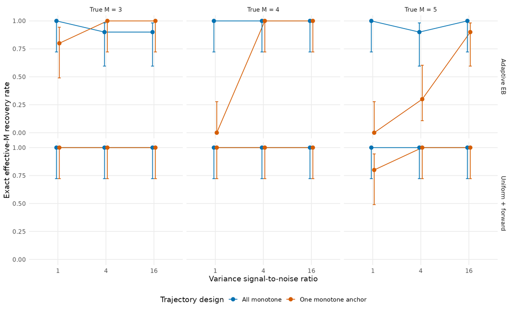

Exact effective-M recovery in the all-monotone and one-monotone-anchor designs. Columns show true M, rows show the estimation method, and color identifies trajectory design. Each point is a proportion out of 10 paired datasets at the labeled variance SNR; error bars are 95% Wilson intervals. Unresolved outcomes contribute to the denominator.

Of the pairs that recover M in the all-monotone setting, adaptive EB loses exact recovery in **29** and gains it in **2** other pairs. Uniform + forward loses exact recovery in **2** and gains it in **0**. The table gives the corresponding counts for each condition.

Paired recovery counts out of 10 datasets per condition and method. Lost exact denotes baseline recovery followed by a non-exact or unresolved modified outcome; gained exact denotes recovery only in the modified design.

| True M | SNR | Method | All monotone: exact | One anchor: exact | Both exact | Lost exact | Gained exact | Unresolved |
| --- | --- | --- | --- | --- | --- | --- | --- | --- |
| 3 | 1 | Adaptive EB | 10 | 8 | 8 | 2 | 0 | 0 |
| 4 | 1 | Adaptive EB | 10 | 0 | 0 | 10 | 0 | 0 |
| 5 | 1 | Adaptive EB | 10 | 0 | 0 | 10 | 0 | 0 |
| 3 | 4 | Adaptive EB | 9 | 10 | 9 | 0 | 1 | 0 |
| 4 | 4 | Adaptive EB | 10 | 10 | 10 | 0 | 0 | 0 |
| 5 | 4 | Adaptive EB | 9 | 3 | 3 | 6 | 0 | 0 |
| 3 | 16 | Adaptive EB | 9 | 10 | 9 | 0 | 1 | 0 |
| 4 | 16 | Adaptive EB | 10 | 10 | 10 | 0 | 0 | 0 |
| 5 | 16 | Adaptive EB | 10 | 9 | 9 | 1 | 0 | 0 |
| 3 | 1 | Uniform + forward | 10 | 10 | 10 | 0 | 0 | 0 |
| 4 | 1 | Uniform + forward | 10 | 10 | 10 | 0 | 0 | 0 |
| 5 | 1 | Uniform + forward | 10 | 8 | 8 | 2 | 0 | 0 |
| 3 | 4 | Uniform + forward | 10 | 10 | 10 | 0 | 0 | 0 |
| 4 | 4 | Uniform + forward | 10 | 10 | 10 | 0 | 0 | 0 |
| 5 | 4 | Uniform + forward | 10 | 10 | 10 | 0 | 0 | 0 |
| 3 | 16 | Uniform + forward | 10 | 10 | 10 | 0 | 0 | 0 |
| 4 | 16 | Uniform + forward | 10 | 10 | 10 | 0 | 0 | 0 |
| 5 | 16 | Uniform + forward | 10 | 10 | 10 | 0 | 0 | 0 |

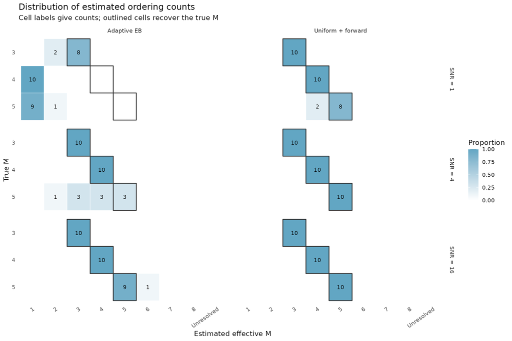

Estimated effective-M distributions for the one-monotone-anchor design. Each row identifies the generating M; columns identify the estimated count, with an additional unresolved category. Panels identify SNR and method. Cell labels give counts out of 10 datasets; fill shows the corresponding proportion, and outlined cells indicate exact recovery.

## Recovery of the underlying structure

Feature-group recovery uses the adjusted Rand index (ARI), assigning each feature to the slot with its highest posterior assignment probability. Ordering recovery matches occupied inferred slots one-to-one to true orderings by absolute Spearman correlation, allowing axis reversal. An unmatched true ordering contributes zero to the mean score. The baseline and modified fits use this same evaluation rule.

Uniform + forward preserves feature grouping closely: mean ARI is **0.995**, compared with **1.000** in the all-monotone study. Its mean ordering score changes from **0.985** to **0.843**. The ordering score averages **0.608 at SNR 1** and **0.999 at SNR 16**, showing that recovering sample positions is more sensitive to noise than recovering the number of feature groups in this design. Adaptive EB’s count losses accompany larger decreases in both feature grouping and ordering recovery.

Mean structural recovery across datasets, with completed paired outcomes shown. ARI measures feature-group recovery; the ordering score is mean absolute Spearman correlation after one-to-one matching. Each design’s mean uses its completed fits.

| Method | All monotone: ARI | One anchor: ARI | All monotone: ordering score | One anchor: ordering score | Completed pairs |
| --- | --- | --- | --- | --- | --- |
| Adaptive EB | 0.996 | 0.730 | 0.985 | 0.685 | 90 |
| Uniform + forward | 1.000 | 0.995 | 0.985 | 0.843 | 90 |

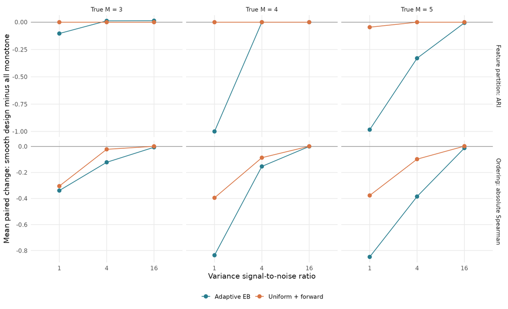

Mean paired change in structural recovery, calculated as the one-monotone-anchor score minus the all-monotone score. The top row shows feature-partition ARI and the bottom row shows matched ordering recovery, with zero assigned to unmatched true orderings. Columns identify true M and colors identify method. Each point averages completed pairs at its SNR; the horizontal zero line indicates equal recovery.

### Preselected examples

These examples use replicate 1 at SNR 4 for each true M. The top row shows the monotone anchor and two smooth trajectories per ordering; the following rows compare true positions with matched inferred positions.

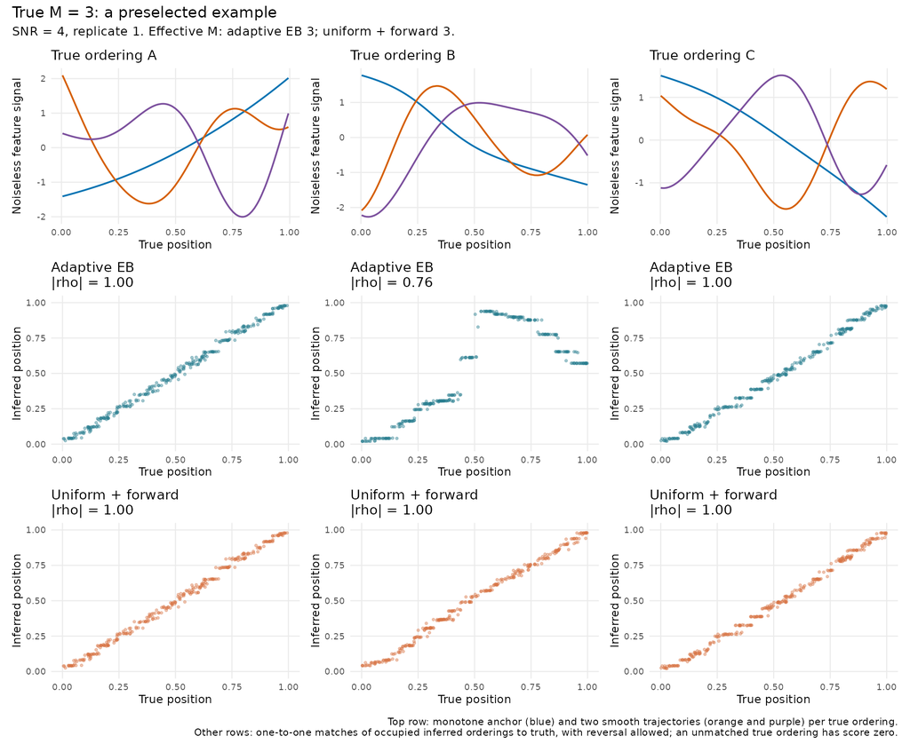

Preselected example with true M = 3, SNR 4, and replicate 1. Top panels show one monotone anchor and two smooth trajectories for each true ordering. The next two rows show matched positions for adaptive EB and uniform + forward. Axes are true and inferred latent positions; labels give absolute Spearman correlations, with reversals chosen consistently for display.

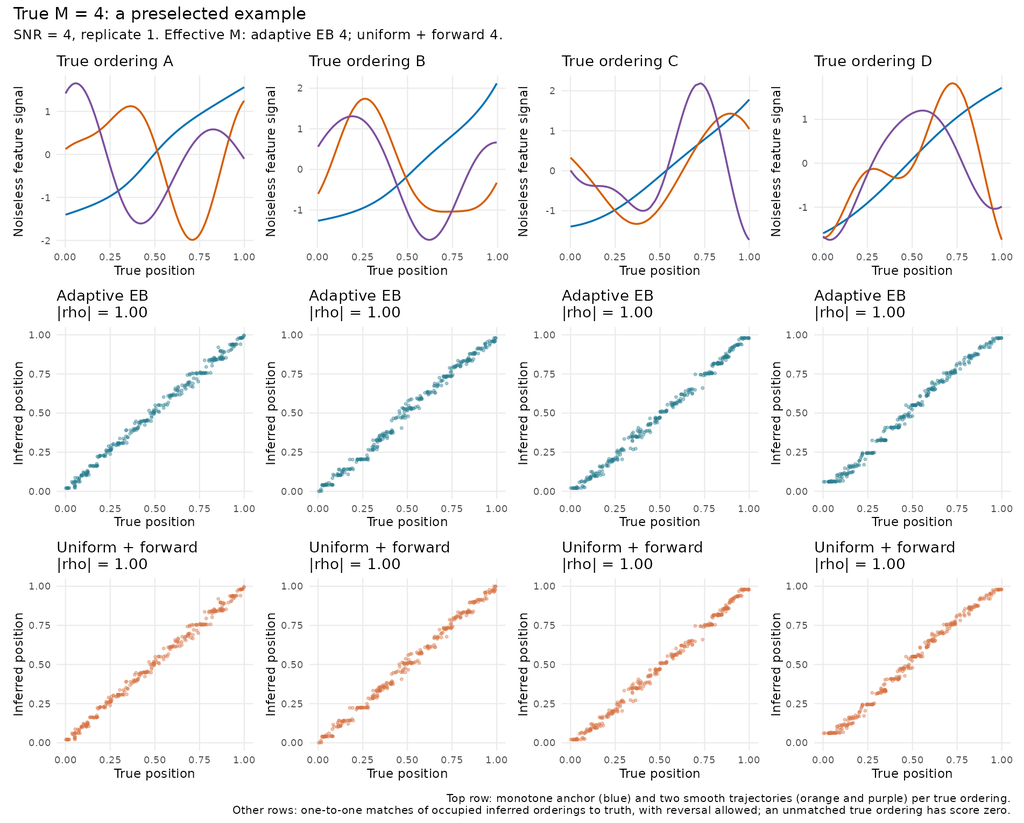

Preselected example with true M = 4, SNR 4, and replicate 1. Columns identify true orderings; top panels show the anchor and two smooth trajectories. Subsequent rows compare true positions with one-to-one matched occupied slots from each method. Unmatched true orderings are labeled explicitly and contribute zero to the recovery score.

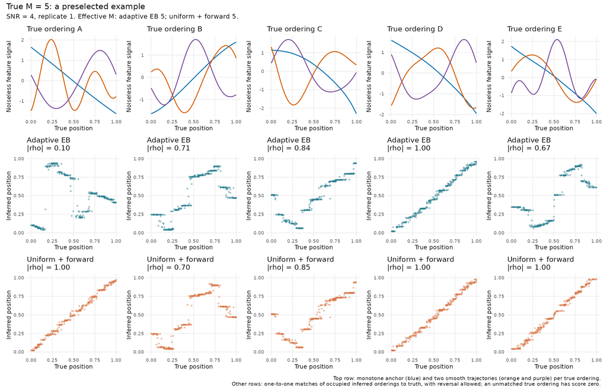

Preselected example with true M = 5, SNR 4, and replicate 1. Top panels show the anchor and two smooth trajectories per ordering. Other panels compare true positions with matched inferred positions for each method, allowing reversal. Panel labels give the absolute Spearman correlation or identify an unmatched ordering or unresolved fit.

## Runtime and convergence

All **180 method runs** produced converged estimates. Runtime includes initialization and every candidate and continuation used by each method, including a forward search’s stopping candidate.

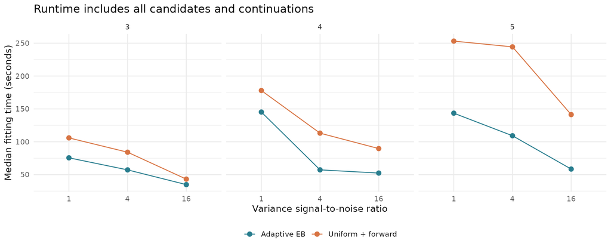

Median fitting time in seconds for each method, true M, and variance SNR in the one-monotone-anchor study. Runtime includes initialization, all fitted candidates, and continuations; forward selection includes its final stopping candidate. Each worker uses one CPU thread.

## Summary and reproduction

The paired experiment changes the non-anchor trajectories while keeping the latent orderings, balanced feature groups, noise, software, and fitting settings fixed. Adaptive EB recovers M in **60/90** modified datasets and uniform + forward in **88/90**, compared with **87/90** and **90/90** in the all-monotone design. The comparison measures the effect of trajectory shape on the complete fitting procedure, including its similarity and Isomap initialization.

The [experiment directory](https://github.com/AgueroZZ/InferOrder/tree/master/experiments/estimate_intrinsic_m_smooth_v032) contains the fixed design and seeds, curve coefficients, input hashes, saved candidates, paired comparison tables, and reproduction scripts. All fits use the original frozen MPCurver 0.3.2 source archive. The shape seed is the original dataset seed plus 2,000,000; pairing and regeneration checks are recorded with the saved inputs.